# Getting down with pagedown: Using R Markdown to create paged HTML documents

Matt Russell, PhD  
17 Oct 2019

Twin Cities R User Group

### About

[figure not shown]

University of Minnesota, Department of Forest Resources

- Associate Professor
- Instruct a graduate class in statstics in natural resources
- Research and outreach on forest health issues

Arbor Custom Analytics LLC

- Consulting for the forest products industry.

### The value of R Markdown

[figure not shown]

Markdown integrates text and R code.

- Reports are fully reproducible
- Supports static and dynamic output formats (e.g., HTML, PDF, MS Word)
- Adapted to use R, Python, and SQL languages

### R Markdown documents facilitate learning R and statistics

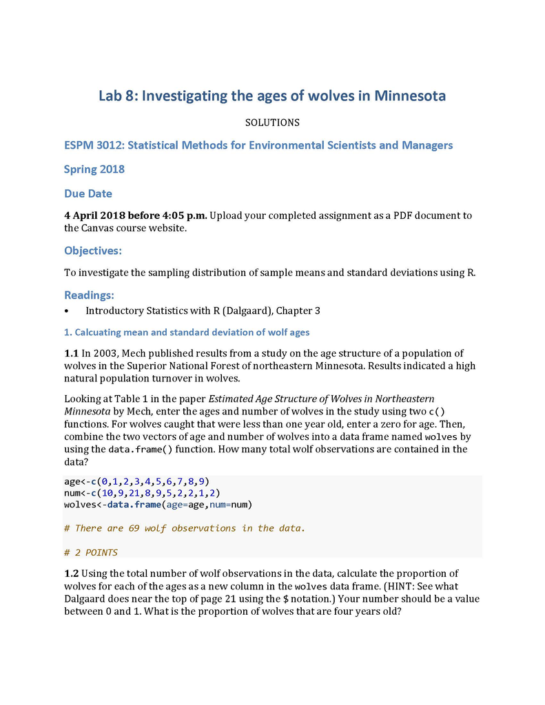

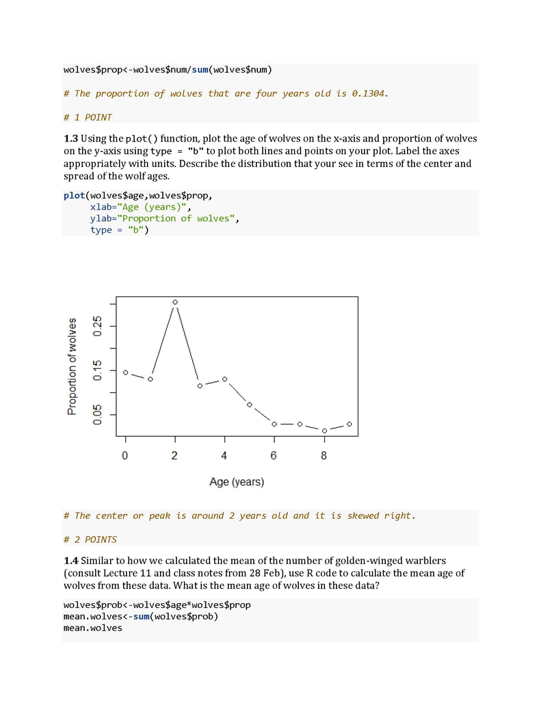

### R Markdown: more than just documents

- Themed documents
- Presentations (like this one!)
- Books (bookdown)
- Dashboards (flexdashboard)
- Websites (blogdown)

[figure not shown]

### What is pagedown?

- Contains output formats for paged HTML documents, letters, resumes, posters, business cards, etc.
- Uses Paged.js (Javascript library) to paginate web documents
- Can include headers, footers, and page margins to make elegant documents

The package can be installed from Github:

```r
remotes::install_github('rstudio/pagedown')
```

### New pagedown file in RStudio

- **File** -> **New File** -> **R Markdown** -> **From Template**
- Several templates available

[figure not shown]

### pagedown:: html_paged

- Creates a paged HTML document.
- Can include table of contents and numbered sections.
- Example: citizen science project showing data.

```r
output:
  pagedown::html_paged:
    toc: true
    number_sections: true
```

### An example: Cover of a paged HTML document

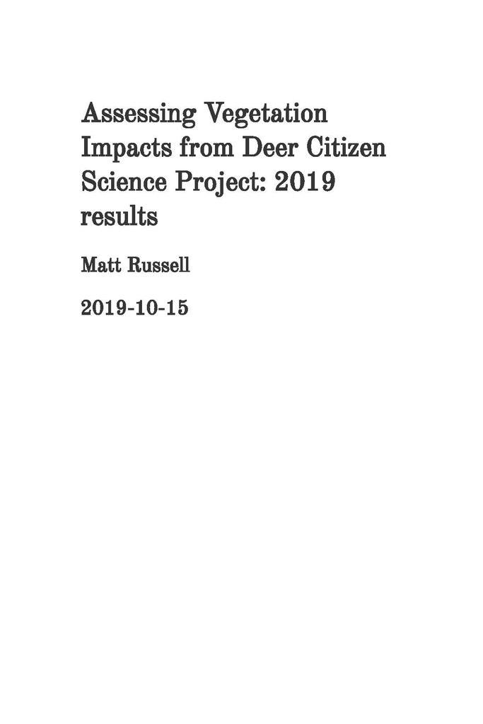

### page 1

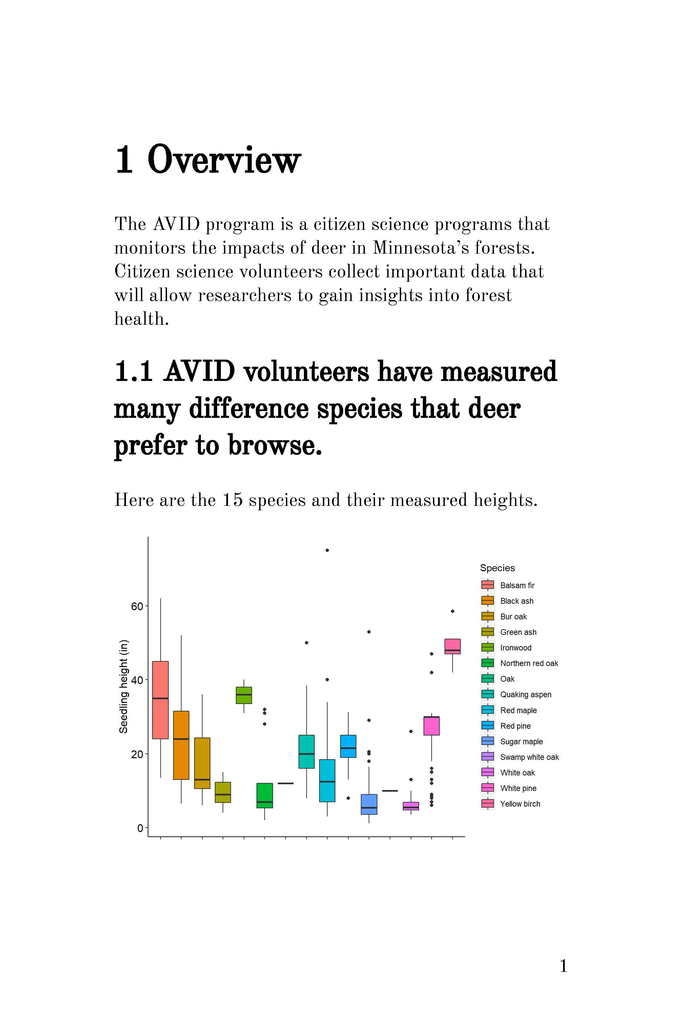

### pages 2-3

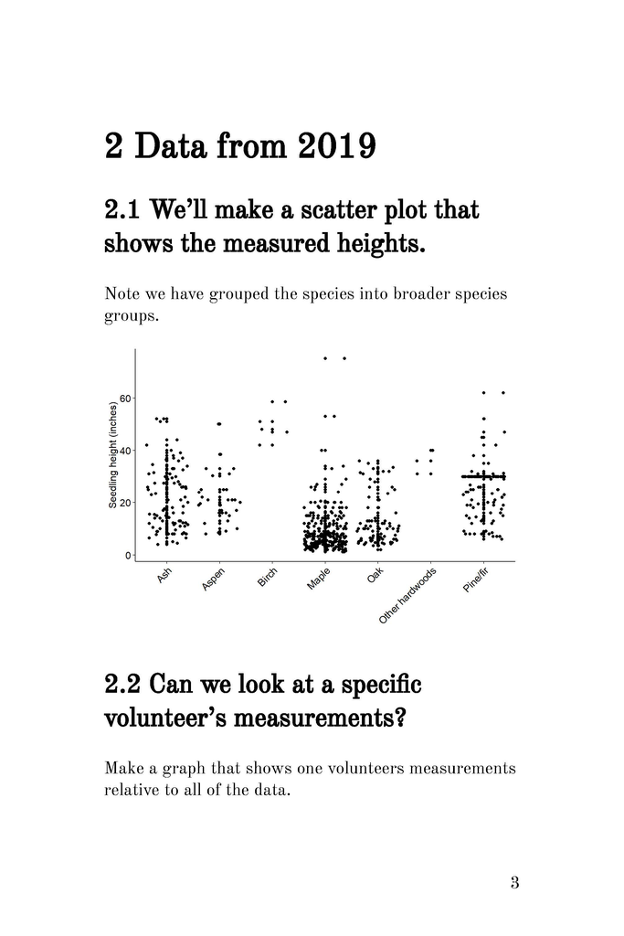

### pages 4-5

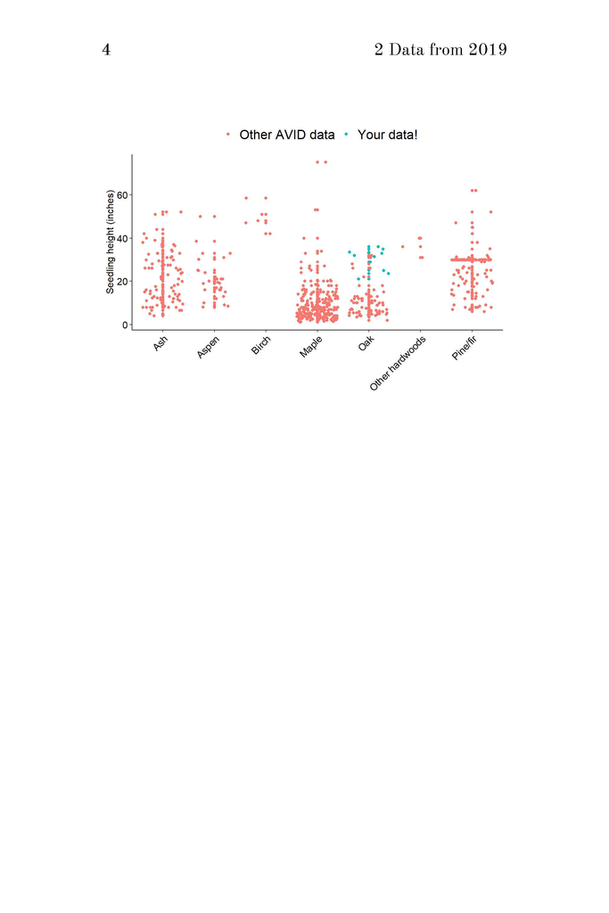

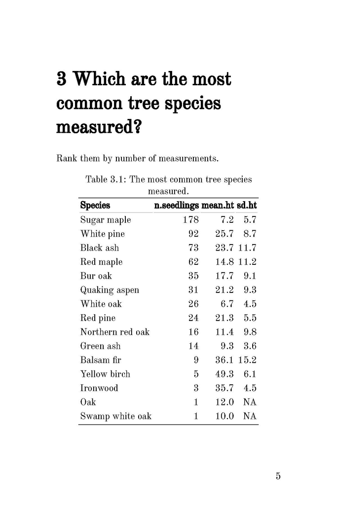

### pages 6-7

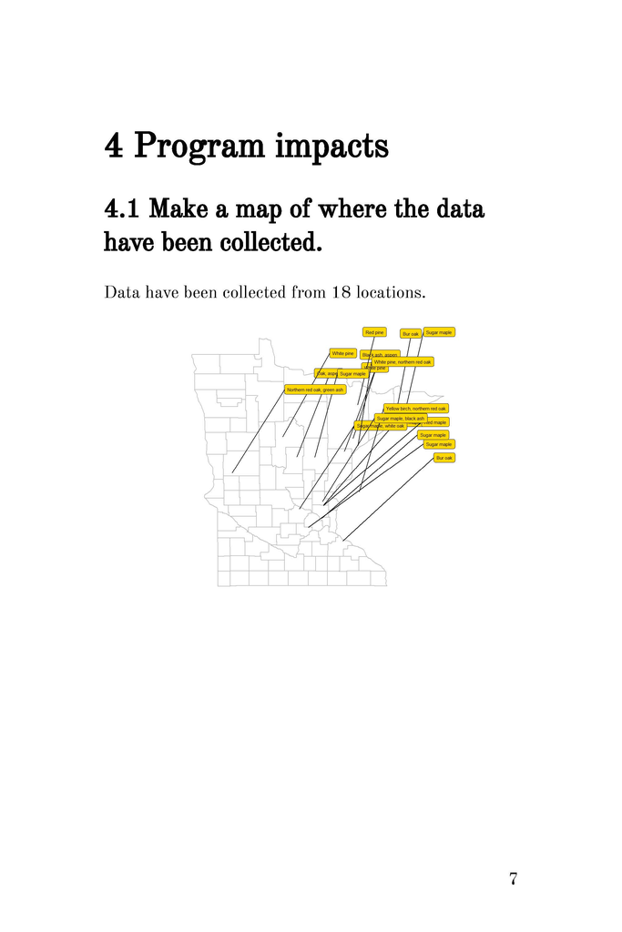

### pagedown::html_resume

- Two parts: an **Aside** and **Main** section

```r
---
title: "resume_example"
author: "Matt Russell"
output: pagedown::html_resume
---
```

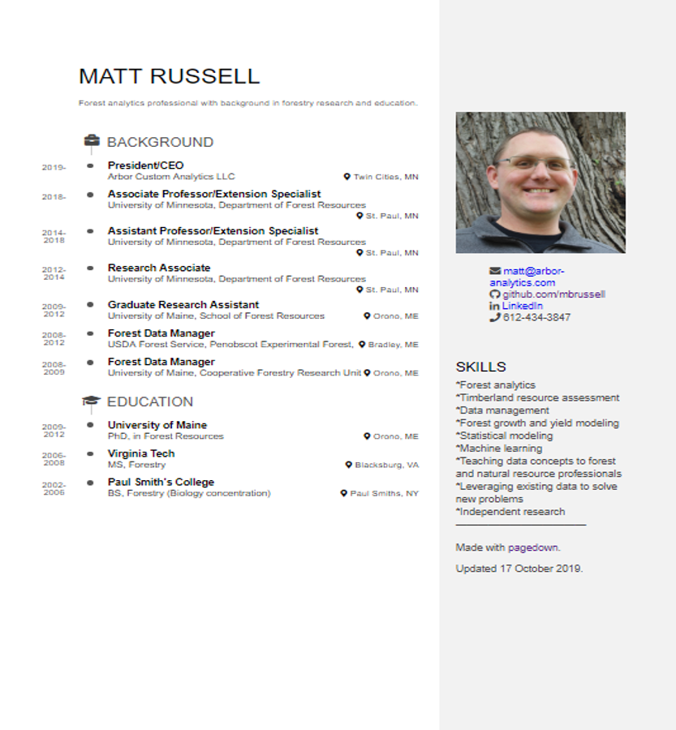

### pagedown::business_card

- Single card for an individual
- Multiple cards for several employees on the same page

```r
---
name: Matt Russell, PhD
output: pagedown::business_card
---
```

[figure not shown]

### Other pagedown documents

- Letters
- Theses/dissertations
- Posters
- Journal articles

Other features

- Cover pages
- Lists of tables and figures
- Custom running headers
- Page references
- Line numbering

[figure not shown]

### Pros/cons of pagedown

Pros

- Create high-quality PDFs through a web browser
- Flexible if you know CSS and Javascript

Cons

- Works best on Chrome or Chromium
- May need to use with `xaringan` to print to web browser (and the “Infinite Moon Reader” function)

```r
xaringan::inf_mr("my_resume.Rmd")
```

### Learn more!

Pagedown documentation

- [pagedown from Github](https://github.com/rstudio/pagedown)
- [pagedown documentation](https://pagedown.rbind.io/)
- VIDEO: [Yihui Xie presentation at rstudio::conf 2019](https://resources.rstudio.com/rstudio-conf-2019/pagedown-creating-beautiful-pdfs-with-r-markdown-and-css)
- SLIDES: [Yihui Xie presentation at rstudio::conf 2019](https://slides.yihui.name/2019-rstudio-conf-pagedown.html#1)

Other applications

- [A quick ride on pagedown](http://www.andreacirillo.com/2019/01/27/a-quick-ride-on-pagedown-create-pdf-from-rmarkdown/). Blog post by Andrea Cirillo.
- [A CV built with pagedown](https://github.com/nstrayer/cv). Code by Nick Strayer.

Thanks to the main authors Yihui Xie and Romain Lesur and other contributors!